# Data visualisation with ggplot

16 January 2021

## Intro

- Based on “grammar of graphics”
- Pros: part of tidyverse, consistent grammar, makes sense, powerful, active community
- Cons: more difficult to start with, computationally intensive

## Sources

- ggplot documentation: http://docs.ggplot2.org/current/
- Great complete tutorial: http://r-statistics.co/Complete-Ggplot2-Tutorial-Part1-With-R-Code.html
- easier tutorials: http://www.noamross.net/blog/2012/10/5/ggplot-introduction.html,
- R Markdown (the tool I used to make these slides), also an R package: https://rmarkdown.rstudio.com/
- grammar of graphics: https://www.springer.com/gp/book/9780387245447

## Layers

Plots are built as a series of layers, e.g.:

- One layer for the box that will contain the plot
- One layer for points
- One layer for lines
- One layer for axes
- One layer for annotations …

## Structure

In particular, ggplots are made of:

- Data
- Aesthetics
- Geometries
- (facets)
- (statistics)
- (coordinates)
- (themes)

## Iris data set

- 150 rows
- 4 measurements
- 1 factor (species) with 3 levels

```r
View(iris)
str(iris)
```

```
## 'data.frame':    150 obs. of  5 variables:
##  $ Sepal.Length: num  5.1 4.9 4.7 4.6 5 5.4 4.6 5 4.4 4.9 ...
##  $ Sepal.Width : num  3.5 3 3.2 3.1 3.6 3.9 3.4 3.4 2.9 3.1 ...
##  $ Petal.Length: num  1.4 1.4 1.3 1.5 1.4 1.7 1.4 1.5 1.4 1.5 ...
##  $ Petal.Width : num  0.2 0.2 0.2 0.2 0.2 0.4 0.3 0.2 0.2 0.1 ...
##  $ Species     : Factor w/ 3 levels "setosa","versicolor",..: 1 1 1 1 1 1 1 1 1 1 ...
```

## Installation

```r
# install.packages('ggplot2')
library(ggplot2)
```

## Scatterplot

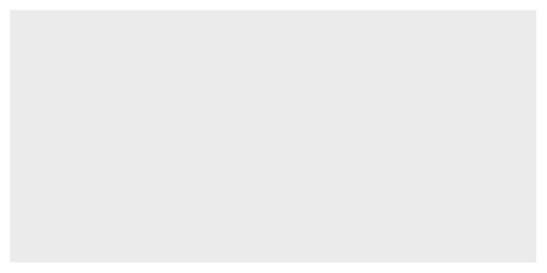

```r
ggplot()
```

Nothing is happening: ggplot is just the first layer

## Scatterplot

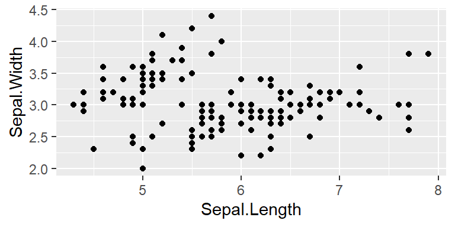

```r
ggplot() + geom_point(data = iris, aes(x = Sepal.Length,
    y = Sepal.Width))
```

## Scatterplot

Plots can be assigned to variables too:

```r
g <- ggplot()
```

And you can add new layers at any point:

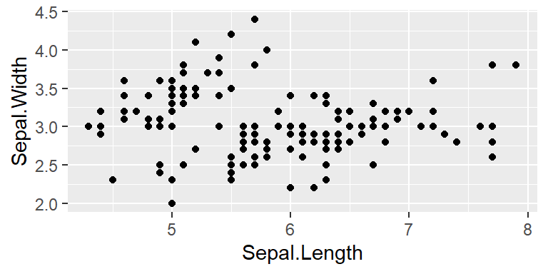

```r
g + geom_point(data = iris, aes(x = Sepal.Length,
    y = Sepal.Width))
```

## Scatterplot

Adding trendline

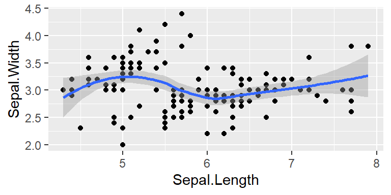

```r
ggplot(data = iris, aes(x = Sepal.Length,
    y = Sepal.Width)) + geom_point() + geom_smooth()
```

## Scatterplot

Regression line

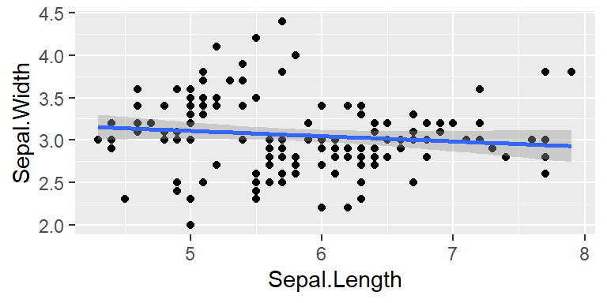

```r
ggplot(data = iris, aes(x = Sepal.Length,
    y = Sepal.Width)) + geom_point() + geom_smooth(method = lm)
```

## Scatterplot

Get rid of the error

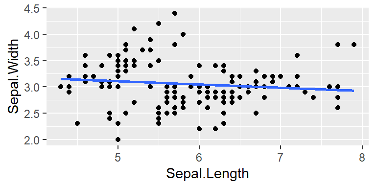

```r
ggplot(data = iris, aes(x = Sepal.Length,
    y = Sepal.Width)) + geom_point() + geom_smooth(method = lm,
    se = F)
```

## Statistical transformations

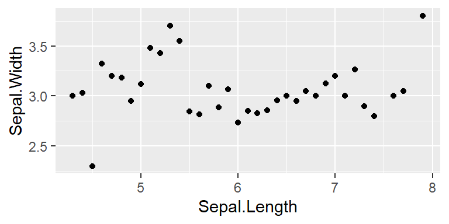

```r
ggplot(data = iris, aes(x = Sepal.Length,
    y = Sepal.Width)) + stat_summary(geom = "point",
    fun = mean)
```

Be careful where you put data and aes: only if all layers have the same data, x and y, then you can put these inside ggplot()

## Statistical transformations

- “fun = mean” is calling “mean()” on the data.
- You can replace “mean()” with e.g. “median()” or even your own function
- You used to need to specify the axis you wanted the transformation on (e.g. “fun.y”), but this is now deprecated. Ggplot guesses what data to transform. If there are ambiguities, try “orientation”

## Grouping (aesthetics)

Adding the grouping factor with colour

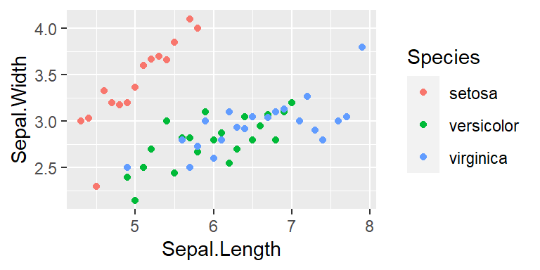

```r
ggplot(data = iris, aes(x = Sepal.Length,
    y = Sepal.Width, color = Species)) +
    stat_summary(geom = "point", fun = mean)
```

## Grouping (aesthetics)

Adding the grouping factor with shape

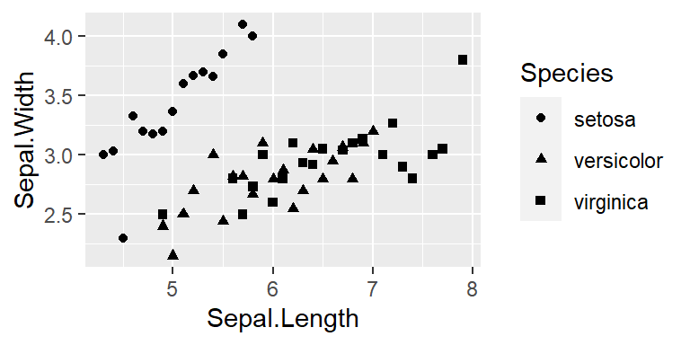

```r
ggplot(data = iris, aes(x = Sepal.Length,
    y = Sepal.Width, shape = Species)) +
    stat_summary(geom = "point", fun = mean)
```

## Grouping (aesthetics)

Colour AND shape, why not!

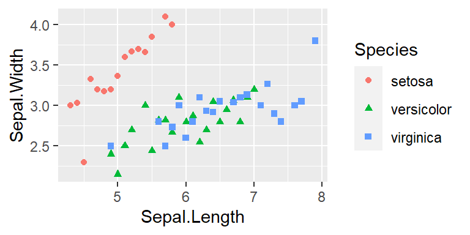

```r
ggplot(data = iris, aes(x = Sepal.Length,
    y = Sepal.Width, shape = Species, color = Species)) +
    stat_summary(geom = "point", fun = mean)
```

## A different geom

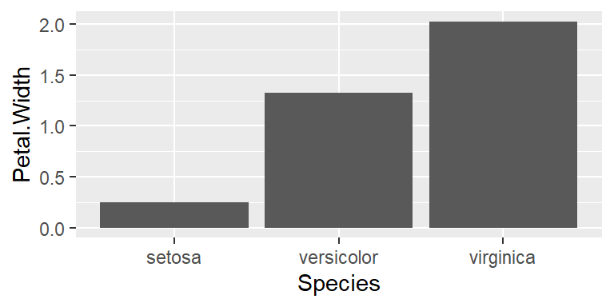

```r
ggplot(data = iris, aes(x = Species, y = Petal.Width)) +
    stat_summary(geom = "bar", fun = mean)
```

```r
# geom_bar(stat = 'identity')
```

## Barplot

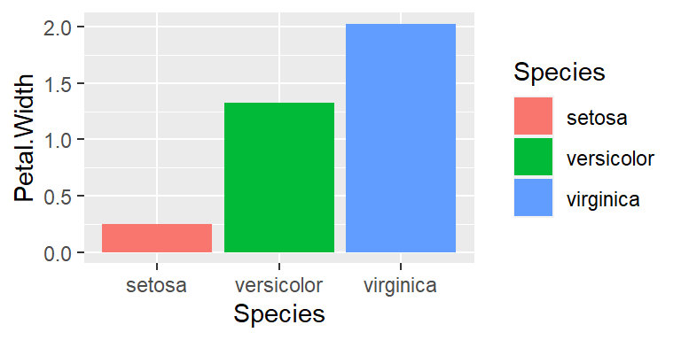

```r
ggplot(data = iris, aes(x = Species, y = Petal.Width,
    fill = Species)) + stat_summary(geom = "bar",
    fun = mean)
```

Notice: “fill” instead of “color”

## Error bars

- With a similar data frame + standard error, we can add error bars

```r
# install.packages('tidyverse')
library(tidyverse)

iris2 <- iris %>% group_by(Species) %>% summarise(N = n(),
    mean = mean(Petal.Width), sd = sd(Petal.Width),
    se = sd/sqrt(50), ci = qt(0.975, N -
        1) * se)

View(iris2)
```

## Error bars

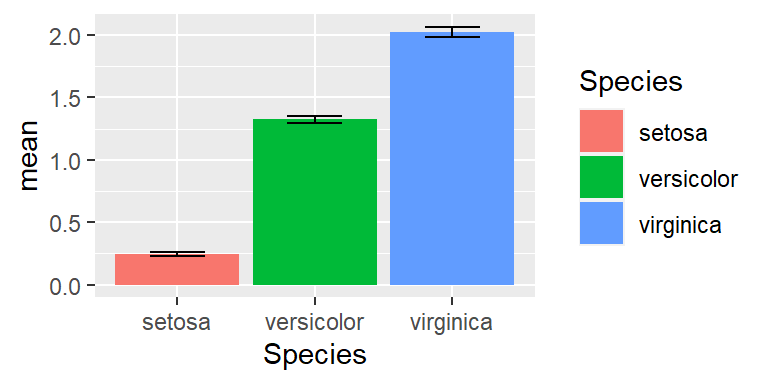

```r
ggplot(data = iris2, aes(x = Species, y = mean,
    fill = Species)) + geom_bar(stat = "identity") +
    geom_errorbar(data = iris2, aes(ymin = mean -
        se, ymax = mean + se), width = 0.4)
```

## Boxplot

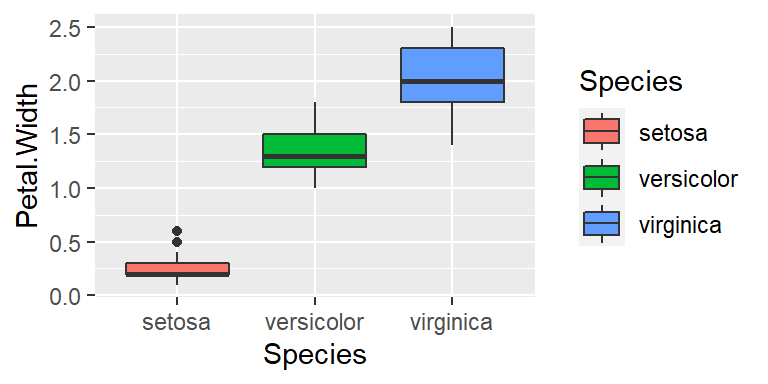

```r
ggplot(data = iris, aes(x = Species, y = Petal.Width,
    fill = Species)) + stat_boxplot()
```

## Line plot

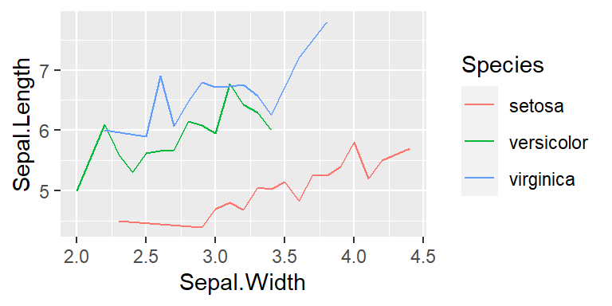

```r
ggplot(data = iris, aes(x = Sepal.Width,
    y = Sepal.Length, color = Species)) +
    stat_summary(fun = mean, geom = "line")
```

What happens if you write `+ geom_line()’ instead of ’stat_summary()?

## Line plot

Lines and points

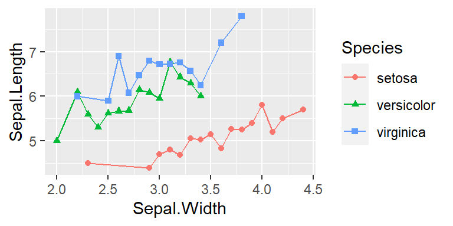

```r
ggplot(data = iris, aes(x = Sepal.Width,
    y = Sepal.Length, color = Species)) +
    stat_summary(fun = mean, geom = "line") +
    stat_summary(fun = mean, geom = "point",
        aes(shape = Species))
```

## More aesthetics modifications

Base plot:

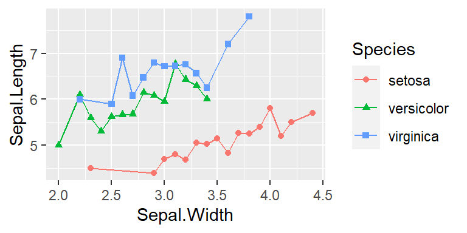

```r
g <- ggplot(data = iris, aes(x = Sepal.Width,
    y = Sepal.Length, color = Species)) +
    stat_summary(fun = mean, geom = "line") +
    stat_summary(fun = mean, geom = "point",
        aes(shape = Species))
g
```

## Axes limits

- Changing the range of the axes

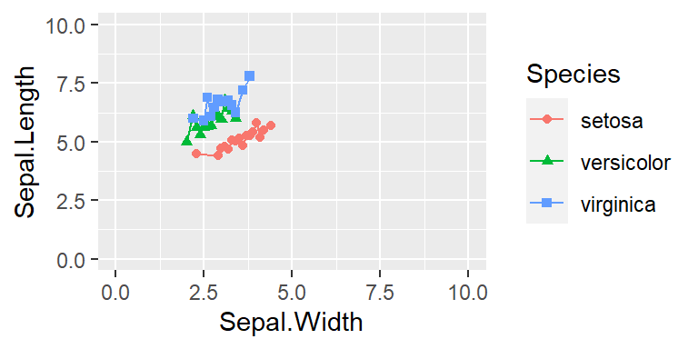

```r
g + xlim(0, 10) + ylim(0, 10)
```

## Element size

- Changing the size of the elements in the graph

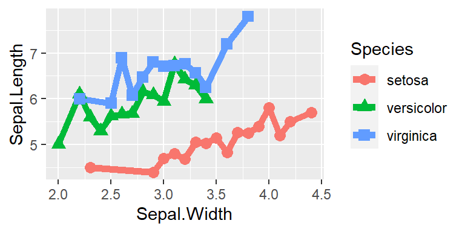

```r
ggplot(data = iris, aes(x = Sepal.Width,
    y = Sepal.Length, color = Species)) +
    stat_summary(fun = mean, geom = "line",
        size = 2) + stat_summary(fun = mean,
    geom = "point", aes(shape = Species),
    size = 3)
```

## Text size

- Changing the size of the text around the graph (theme layer)

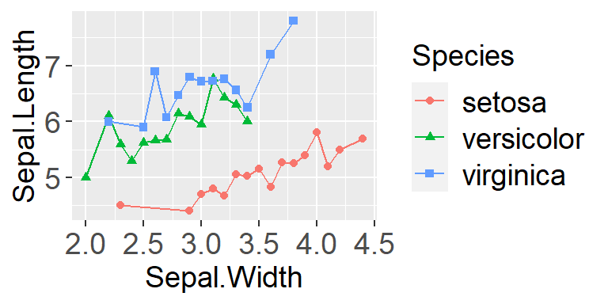

```r
g + theme(axis.text = element_text(size = 14),
    legend.text = element_text(size = 14),
    legend.title = element_text(size = 14),
    axis.title = element_text(size = 14))
```

## Axes names

- Changing the axes names

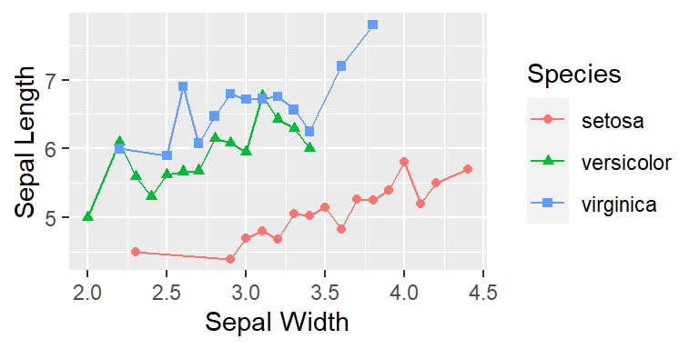

```r
g + labs(x = "Sepal Width", y = "Sepal Length")
```

## Title

- Adding a title

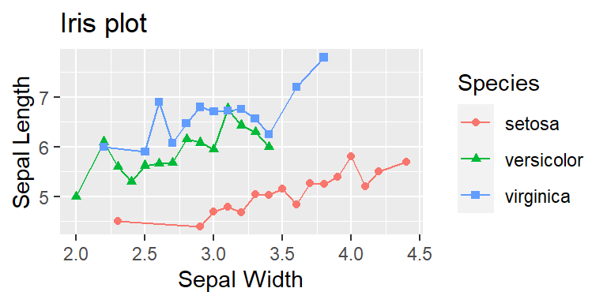

```r
g + labs(x = "Sepal Width", y = "Sepal Length",
    title = "Iris plot")
```

## Title

- Adding a title in a different way

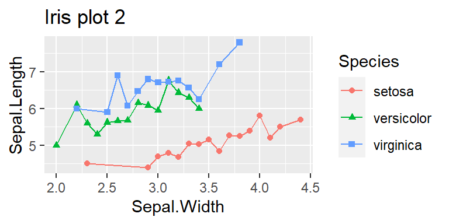

```r
g + ggtitle("Iris plot 2")
```

## Colours!

- Custom colours

```r
coll <- c("violetred", "darkblue", "lightgreen")
```

Allowed names: http://www.stat.columbia.edu/~tzheng/files/Rcolor.pdf

## Colours

- Custom colours

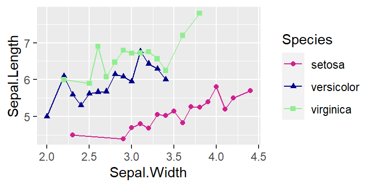

```r
g + scale_color_manual(values = coll)
```

## Colours

- Semi Custom colours

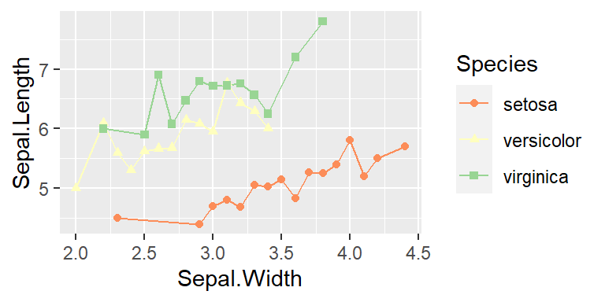

```r
g + scale_color_brewer(palette = "Spectral")
```

Some palette choices here: http://www.r-bloggers.com/choosing-colour-palettes-part-ii-educated-choices/

## Colours

- Grey scales

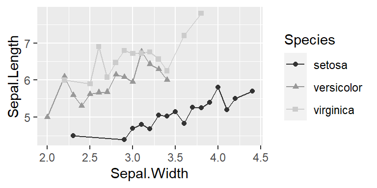

```r
g + scale_color_grey()
```

## Legend

- Change legend title and names

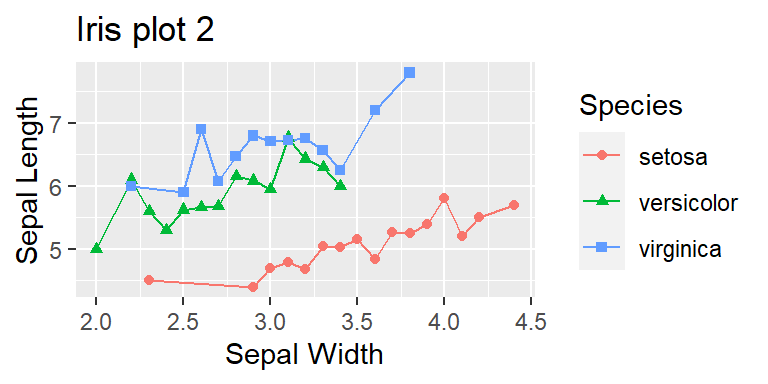

```r
g <- ggplot(data = iris, aes(x = Sepal.Width,
    y = Sepal.Length, color = Species)) +
    stat_summary(fun = mean, geom = "line") +
    stat_summary(fun = mean, geom = "point",
        aes(shape = Species)) + labs(x = "Sepal Width",
    y = "Sepal Length") + ggtitle("Iris plot 2")

g
```

## Legend

- Change legend title and names

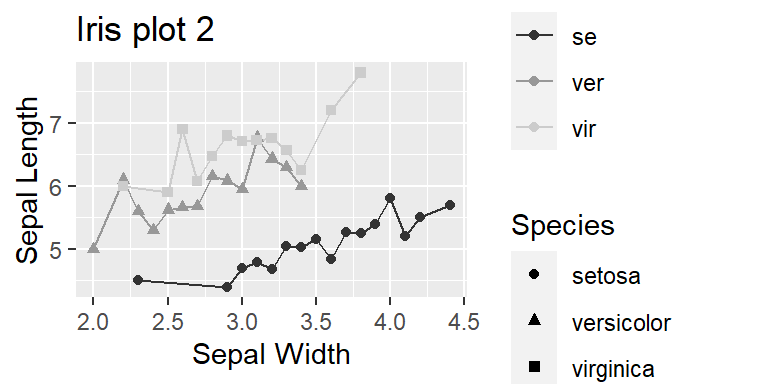

```r
g + scale_color_grey(name = "New Legend Title",
    labels = c("se", "ver", "vir"))
```

But this creates 2 different legends!

## Legend

- The reason is that we only specified the “colour” layer to have a new legend
- We need to specify the “shape” layer as well!

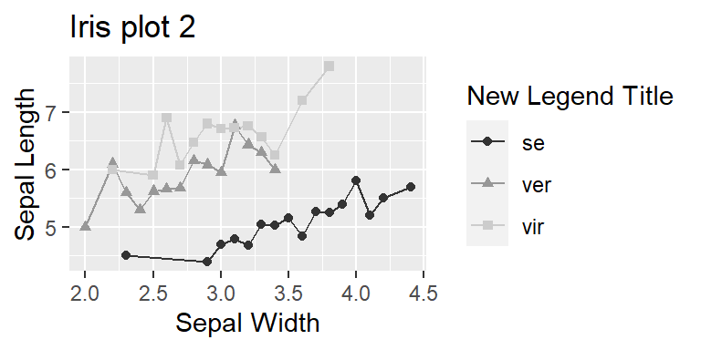

```r
g + scale_color_grey(name = "New Legend Title",
    labels = c("se", "ver", "vir")) + scale_shape_discrete(name = "New Legend Title",
    labels = c("se", "ver", "vir"))
```

## Legend

Or define the labels in a variable

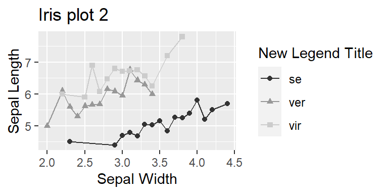

```r
new_labels <- c("se", "ver", "vir")

g + scale_color_grey(name = "New Legend Title",
    labels = new_labels) + scale_shape_discrete(name = "New Legend Title",
    labels = c("se", "ver", "vir"))
```

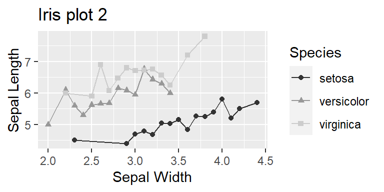

```r
g <- g + scale_color_grey()

g
```

## Legend

- Delete legend or part of

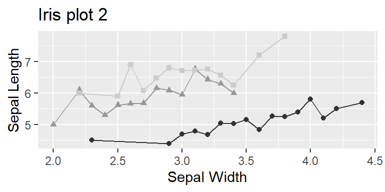

```r
g + guides(color = "none", shape = "none")
```

## Legend

- Delete legend or part of: Just leave the "" empty

## Themes

- Print-friendly

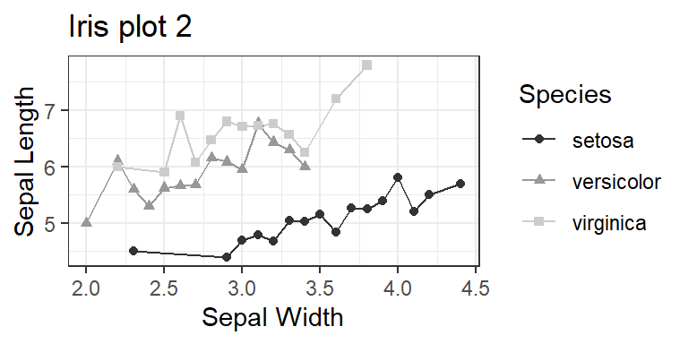

```r
g + theme_bw()
```

## Additional themes

- Collection of themes, including a replica of Stata graph schemes: https://github.com/jrnold/ggthemes
- APA-themed ggplot template: https://sakaluk.wordpress.com/2015/04/13/2-the-ggplot2-package-your-gateway-drug-to-becoming-an-r-user/

## Additional themes

Example of the aforementioned APA theme:

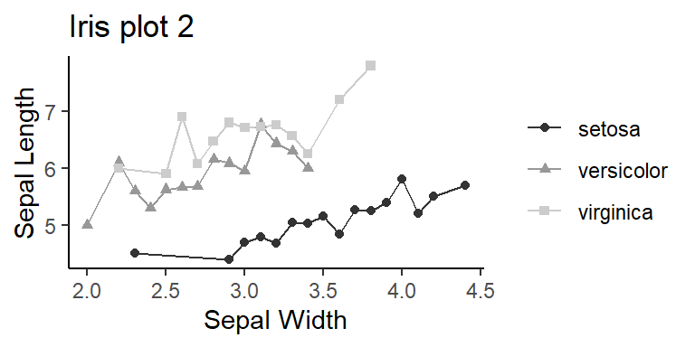

```r
# windowsFonts(Times=windowsFont('TT
# Times New Roman'))

apatheme = theme_bw() + theme(panel.grid.major = element_blank(),
    panel.grid.minor = element_blank(), panel.border = element_blank(),
    axis.line = element_line(), text = element_text(family = "Times"),
    legend.title = element_blank())

g + apatheme
```

Note: the font family argument caused the following error in my machine: “Font family not found in Windows font database”. I solved it by running the windowsFonts() function just above. You might not encounter this error though!

## Additional themes

Game of thrones palette!! https://github.com/aljrico/gameofthrones

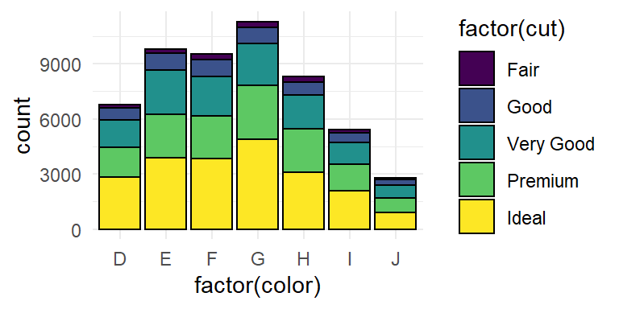

```r
# install.packages('gameofthrones')
library(gameofthrones)

t <- ggplot(diamonds, aes(factor(color),
    fill = factor(cut))) + geom_bar(colour = "black") +
    theme_minimal()

t
```

## Additional themes

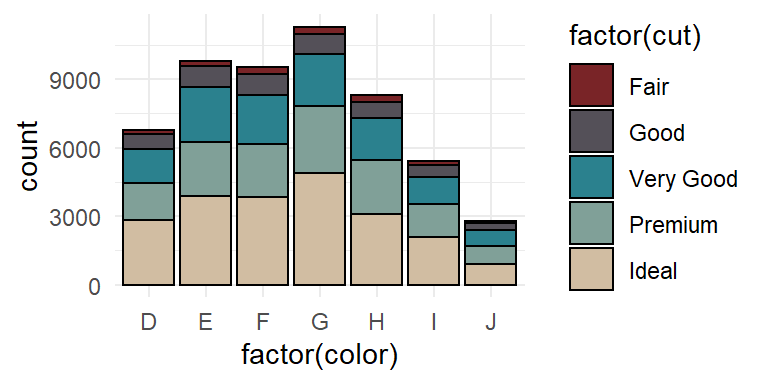

```r
t + scale_fill_got(discrete = TRUE, option = "Daenerys")
```

## Additional themes

Harry Potter palette!!! https://github.com/aljrico/harrypotter

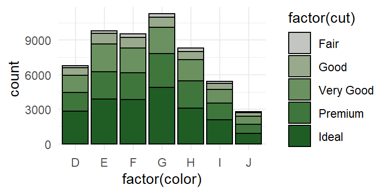

```r
# install.packages('harrypotter')
library(harrypotter)

t + scale_fill_hp(discrete = TRUE, house = "slytherin")
```

## Faceting

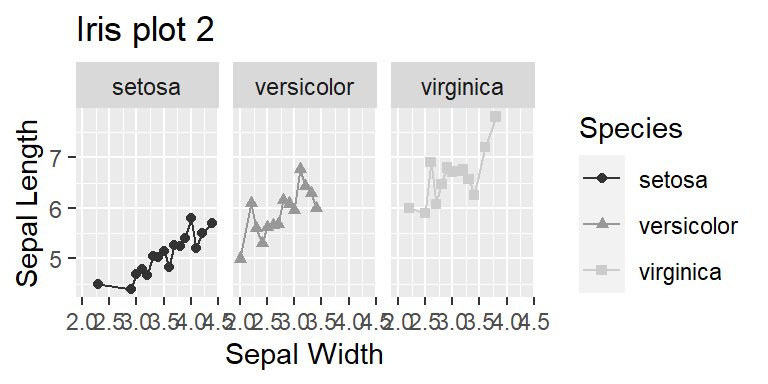

```r
g + facet_wrap(~Species)
```

## Faceting

- 2 grouping variables
- Iris only has one so I will add another one

```r
iris2 <- iris
iris2$fac <- c("a", "b", "c")

View(iris2)
```

## Faceting

```r
g <- ggplot(data = iris2, aes(x = Sepal.Width,
    y = Sepal.Length, color = Species)) +
    stat_summary(fun = mean, geom = "line") +
    stat_summary(fun = mean, geom = "point",
        aes(shape = Species)) + theme(axis.text = element_text(size = 14),
    legend.text = element_text(size = 14),
    legend.title = element_text(size = 14),
    axis.title = element_text(size = 14)) +
    labs(x = "Sepal Width", y = "Sepal Length") +
    ggtitle("Iris plot 2") + scale_color_grey() +
    theme_bw()
```

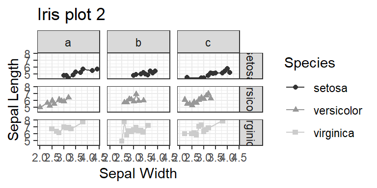

```r
g + facet_grid(Species ~ fac)
```

## Saving plot

```r
ggsave(g, file = "g.pdf")
ggsave(g, file = "g.png")
```

You can also run the regular pdf() or png() functions. ggsave will understand the format you want to save in from the file name extension.

## Saving plot

```r
ggsave(g, file = "g.png", width = 10, height = 4,
    units = "cm")
```

## Tidyverse integration

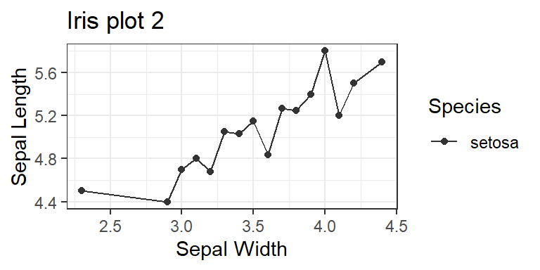

```r
iris %>% filter(Species == "setosa") %>%
    ggplot(aes(x = Sepal.Width, y = Sepal.Length,
        color = Species)) + stat_summary(fun = mean,
    geom = "line") + stat_summary(fun = mean,
    geom = "point", aes(shape = Species)) +
    theme(axis.text = element_text(size = 14),
        legend.text = element_text(size = 14),
        legend.title = element_text(size = 14),
        axis.title = element_text(size = 14)) +
    labs(x = "Sepal Width", y = "Sepal Length") +
    ggtitle("Iris plot 2") + scale_color_grey() +
    theme_bw()
```

## Questions?

Thank you!

Dr. Ilaria Torre ilariat@kth.se

@ilaria_torre11

https://www.kth.se/profile/ilariat